# FIA - NLS Models: Biomass vs. Stand Age, G-Reconciled, Temporally-balanced, No Harvest – Log-Normal

## predict and plot

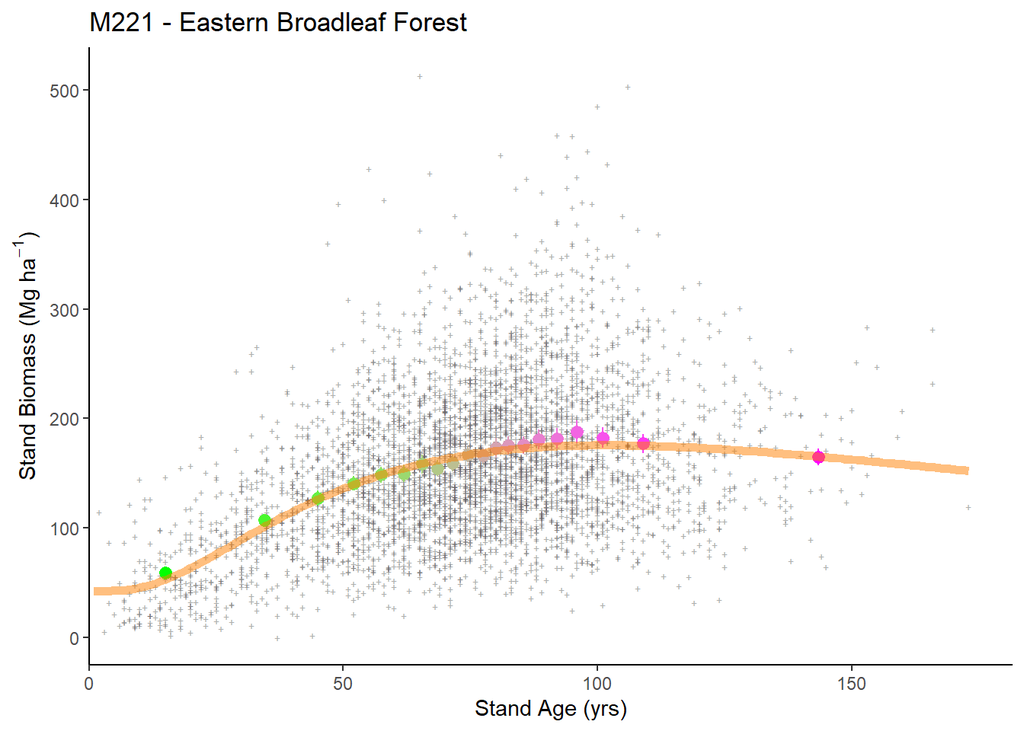

## plotting 2

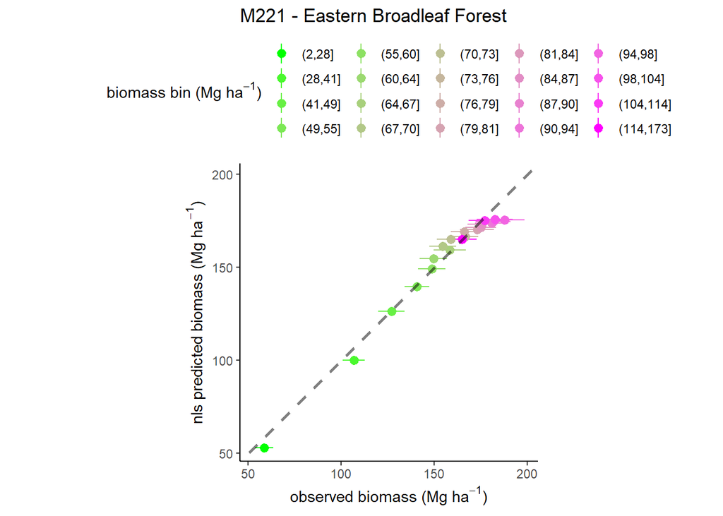

# M223 - Ozark Broadleaf Forest Meadow

## model selection 1

```
## Analysis of Variance Table
##
## Model 1: B_plt_t2_MgHa ~ (1 + (MEASTIME_t2 - 1990) * ge/100) * (a + b * exp(-((log(STDAGE_t2/c))/d)^2))
## Model 2: B_plt_t2_MgHa ~ (1 + (MEASTIME_t2 - 1990) * ge/100) * (1 + phi * DeltaPDSI) * (a + b * exp(-((log(STDAGE_t2/c))/d)^2))
## Model 3: B_plt_t2_MgHa ~ (1 + (MEASTIME_t2 - 1990) * ge/100) * (1 + phi * DeltaPDSI) * (1 - alpha * B_L_prop) * (a + b * exp(-((log(STDAGE_t2/c))/d)^2))
##   Res.Df Res.Sum Sq Df Sum Sq F value    Pr(>F)
## 1    516     62.223
## 2    515     60.133  1 2.0897  17.897 2.760e-05 ***
## 3    514     56.623  1 3.5101  31.863 2.738e-08 ***
## ---
## Signif. codes:  0 '***' 0.001 '**' 0.01 '*' 0.05 '.' 0.1 ' ' 1
##   model      AIC
## 1     1 5303.397
## 2     2 5287.599
## 3     3 5258.263
```

```
##
## Formula: B_plt_t2_MgHa ~ (1 + (MEASTIME_t2 - 1990) * ge/100) * (1 + phi *
##     DeltaPDSI) * (1 - alpha * B_L_prop) * (a + b * exp(-((log(STDAGE_t2/c))/d)^2))
##
## Parameters:
##         Estimate Std. Error t value Pr(>|t|)
## ge      -0.74499    0.25796  -2.888 0.004040 **
## phi      0.09536    0.02452   3.889 0.000114 ***
## alpha    0.94100    0.15705   5.992  3.9e-09 ***
## a        0.00000   76.43530   0.000 1.000000
## b      271.18231  458.90727   0.591 0.554827
## c      730.26198 3801.09194   0.192 0.847725
## d        2.93076    3.79803   0.772 0.440675
## ---
## Signif. codes:  0 '***' 0.001 '**' 0.01 '*' 0.05 '.' 0.1 ' ' 1
##
## Residual standard error: 0.3319 on 514 degrees of freedom
##
## Algorithm "port", convergence message: relative convergence (4)
##   (1 observation deleted due to missingness)
```

### summary

- simple model: fits
- phi model: fits
- phi-alpha model: fits

## plot residuals

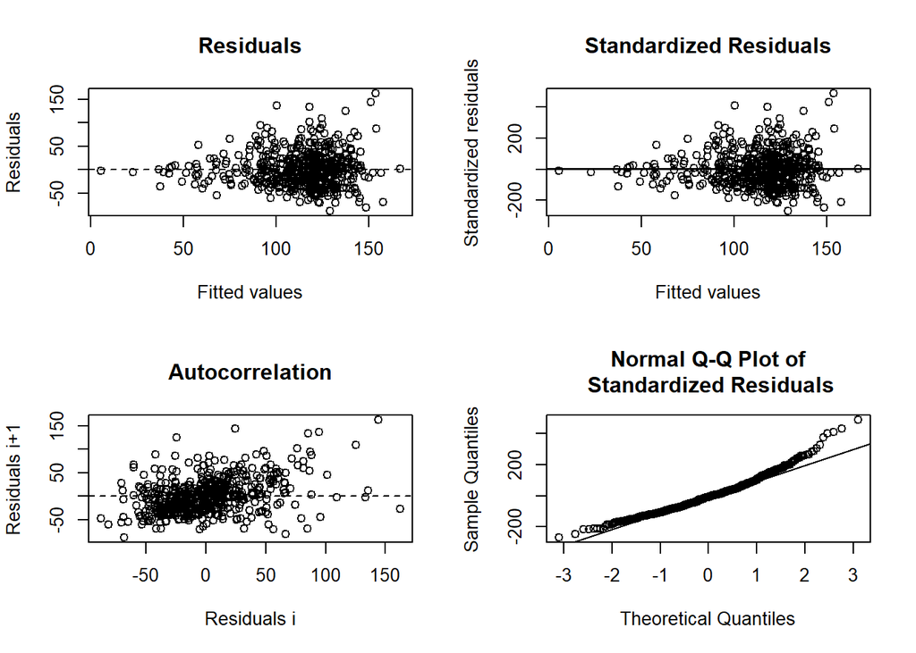

```
##
## ------
##  Shapiro-Wilk normality test
##
## data:  stdres
## W = 0.96691, p-value = 1.901e-09
##
##
## ------
```

```
##
##  Runs Test
##
## data:  as.factor(run)
## Standard Normal = -7.261, p-value = 3.843e-13
## alternative hypothesis: two.sided
```

## predict and plot

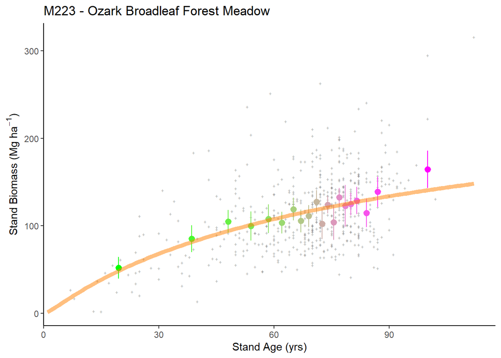

## plotting 2

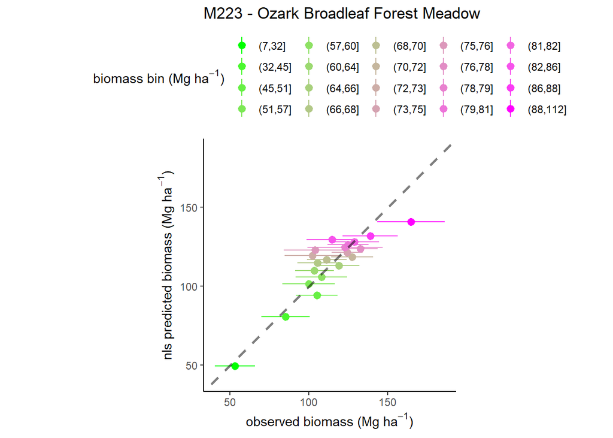

# M231 - Ouachita Mixed Forest

## model selection 1

```
## Analysis of Variance Table
##
## Model 1: B_plt_t2_MgHa ~ (1 + (MEASTIME_t2 - 1990) * ge/100) * (a + b * exp(-((log(STDAGE_t2/c))/d)^2))
## Model 2: B_plt_t2_MgHa ~ (1 + (MEASTIME_t2 - 1990) * ge/100) * (1 + phi * DeltaPDSI) * (a + b * exp(-((log(STDAGE_t2/c))/d)^2))
## Model 3: B_plt_t2_MgHa ~ (1 + (MEASTIME_t2 - 1990) * ge/100) * (1 + phi * DeltaPDSI) * (1 - alpha * B_L_prop) * (a + b * exp(-((log(STDAGE_t2/c))/d)^2))
##   Res.Df Res.Sum Sq Df Sum Sq F value   Pr(>F)
## 1    578     113.06
## 2    577     112.95  1 0.1107  0.5655 0.452359
## 3    576     111.27  1 1.6842  8.7188 0.003278 **
## ---
## Signif. codes:  0 '***' 0.001 '**' 0.01 '*' 0.05 '.' 0.1 ' ' 1
##   model      AIC
## 1     1 6038.106
## 2     2 6039.535
## 3     3 6032.777
```

```
##
## Formula: B_plt_t2_MgHa ~ (1 + (MEASTIME_t2 - 1990) * ge/100) * (1 + phi *
##     DeltaPDSI) * (1 - alpha * B_L_prop) * (a + b * exp(-((log(STDAGE_t2/c))/d)^2))
##
## Parameters:
##        Estimate Std. Error t value Pr(>|t|)
## ge    1.628e-01  5.460e-01   0.298   0.7657
## phi   1.741e-02  2.895e-02   0.601   0.5479
## alpha 7.021e-01  2.293e-01   3.063   0.0023 **
## a     0.000e+00  4.992e+01   0.000   1.0000
## b     2.459e+02  4.589e+02   0.536   0.5924
## c     7.790e+02  3.981e+03   0.196   0.8449
## d     2.684e+00  3.328e+00   0.807   0.4202
## ---
## Signif. codes:  0 '***' 0.001 '**' 0.01 '*' 0.05 '.' 0.1 ' ' 1
##
## Residual standard error: 0.4395 on 576 degrees of freedom
##
## Algorithm "port", convergence message: relative convergence (4)
##   (1 observation deleted due to missingness)
```

### summary

- simple model: fits
- phi model: fits
- phi-alpha model: fits

## plot residuals

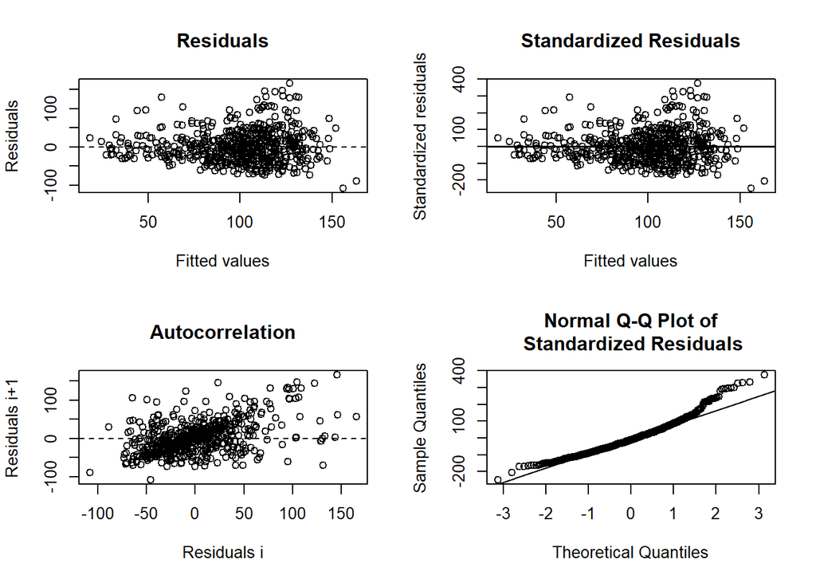

```
##
## ------
##  Shapiro-Wilk normality test
##
## data:  stdres
## W = 0.95793, p-value = 7.455e-12
##
##
## ------
```

```
##
##  Runs Test
##
## data:  as.factor(run)
## Standard Normal = -10.168, p-value < 2.2e-16
## alternative hypothesis: two.sided
```

## predict and plot

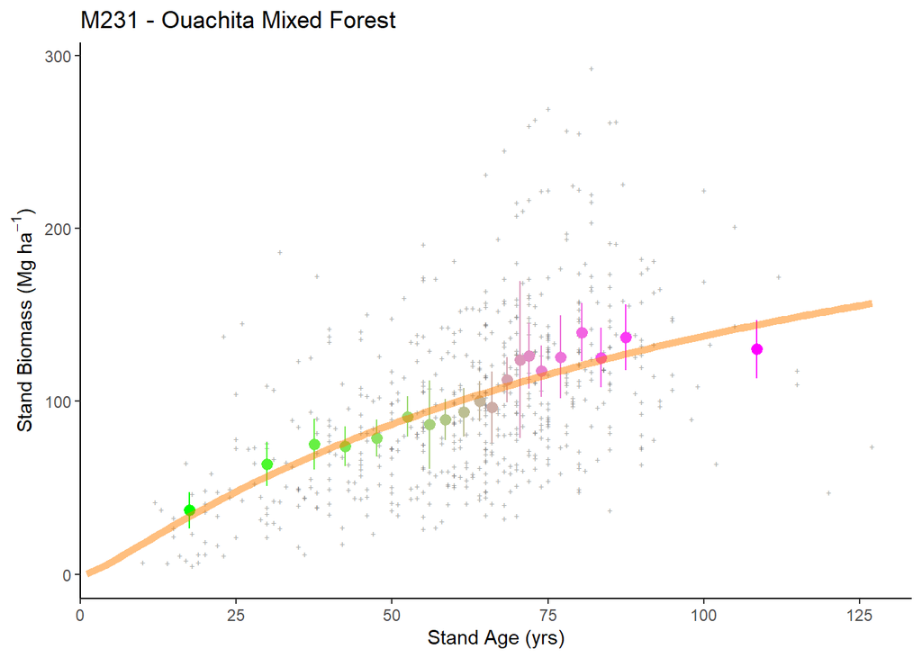

## plotting 2

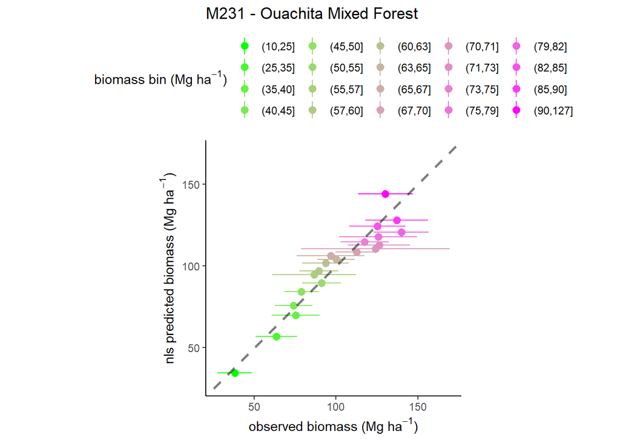

# M242 - Cascade Mixed Forest

## model selection 1

### summary

- simple model: does not fit
- phi model: does not fit
- phi-alpha model: does not fit

## plot residuals

```
## [1] "cannot plot residuals"
```

## predict and plot

```
## [1] "cannot plot data with prediction"
```

## plotting 2

```
## [1] "cannot plot observed vs. predicted"
```

# M261 - Sierran Steppe - Mixed Forest - Coniferous Forest - Alpine Meadow

## model selection 1

[output not shown]

### summary

- simple model: does not fit
- phi model: does not fit
- phi-alpha model: does not fit

## plot residuals

```
## [1] "cannot plot residuals"
```

## predict and plot

```
## [1] "cannot plot data with prediction"
```

## plotting 2

[output not shown]

# M262 - California coastal range - coniferous forest - open woodland - shrub meadow

## Model selection 1

### summary

- simple model: does not fit
- phi model: does not fit
- phi-alpha model: does not fit

## plot residuals

```
## [1] "cannot plot residuals"
```

## predict and plot

```
## [1] "cannot plot data with prediction"
```

## plotting 2

# M313 - Arizona-New Mexico Mountains Semi-Desert - Open Woodland - Coniferous Forest - Alpine Meadow

## model selection 1

[output not shown]

```
## Error in get(paste("nls_M313.", Mod.Sel1, sep = "")) :
##   object 'nls_M313.' not found
```

### summary

- simple model: does not fit
- phi model: does not fit
- phi-alpha model: does not fit

## plot residuals

```
## [1] "cannot plot residuals"
```

## predict and plot

```
## [1] "cannot plot data with prediction"
```

## plotting 2

# M331 - Southern Rocky Mountain Steppe - Open Woodland - Coniferous Forest - Alpine Meadow

## model selection 1

[output not shown]

```
## Error in get(paste("nls_M331.", Mod.Sel1, sep = "")) :
##   object 'nls_M331.' not found
```

### summary

- simple model: does not fit
- phi model: does not fit
- phi-alpha model: does not fit

## plot residuals

```
## [1] "cannot plot residuals"
```

## predict and plot

```
## [1] "cannot plot data with prediction"
```

## plotting 2

# M332 - Middle Rocky Mountain Steppe - Coniferous Forest - Alpine Meadow

## model selection 1

### summary

- simple model: does not fit
- phi model: does not fit
- phi-alpha model: does not fit

## plot residuals

```
## [1] "cannot plot residuals"
```

## predict and plot

```
## [1] "cannot plot data with prediction"
```

## plotting 2

# M333 - Northern Rocky Mountain Steppe - Coniferous Forest - Alpine Meadow

## model selection 1

[output not shown]

```
## Error in get(paste("nls_M333.", Mod.Sel1, sep = "")) :
##   object 'nls_M333.' not found
```

### summary

- simple model: does not fit
- phi model: does not fit
- phi-alpha model: does not fit

## plot residuals

```
## [1] "cannot plot residuals"
```

## predict and plot

```
## [1] "cannot plot data with prediction"
```

## plotting 2

# M334 - Black Hills Coniferous Forest

## model selection 1

[output not shown]

```
## Error in get(paste("nls_M334.", Mod.Sel1, sep = "")) :
##   object 'nls_M334.' not found
```

### summary

- simple model: does not fit
- phi model: does not fit
- phi-alpha model: does not fit

## plot residuals

```
## [1] "cannot plot residuals"
```

## predict and plot

```
## [1] "cannot plot data with prediction"
```

## plotting 2

# M341 - Nevada-Utah Mountains Semi-Desert - Coniferous Forest - Alpine Meadow

## model selection 1

[output not shown]

```
## Error in get(paste("nls_M341.", Mod.Sel1, sep = "")) :
##   object 'nls_M341.' not found
```

### summary

- simple model: does not fit
- phi model: does not fit
- phi-alpha model: does not fit

## plot residuals

```
## [1] "cannot plot residuals"
```

## predict and plot

```
## [1] "cannot plot data with prediction"
```

## plotting 2

# Fitted parameters

## Best / selected models by ecoprovince

| Code | Ecoregion | Sel.Mod |
| --- | --- | --- |
| 211 | Northeastern Mixed Forest | 3 |
| 212 | Laurentian Mixed Forest | 3 |
| 221 | Eastern Broadleaf Forest | 3 |
| 222 | Midwest Broadleaf Forest | 3 |
| 223 | Central Interior Broadleaf Forest | 3 |
| 231 | Southeastern Mixed Forest | 3 |
| 232 | Outer Coastal Plain Mixed Forest | 3 |
| 234 | Lower Mississippi Riverine Forest | NA |
| 242 | Pacific Lowland Mixed Forest | NA |
| 251 | Prairie Parkland (Temperate) | 3 |
| 255 | Prairie Parkland (Subtropical) | 3 |
| 261 | California Coastal Chaparral Forest and Shrub | NA |
| 262 | California Dry Steppe | NA |
| 263 | California Coastal Steppe - Mixed Forest and Redwood Forest | NA |
| 313 | Colorado Plateau Semi-Desert | NA |
| 315 | Southwest Plateau and Plains Dry Steppe and Shrub | NA |
| 321 | Chihuahuan Semi-Desert | NA |
| 322 | American Semidesert and Desert | NA |
| 331 | Great Plains/Palouse Dry Steppe | NA |
| 332 | Great Plains Steppe | NA |
| 341 | Intermountain Semi-Desert and Desert | NA |
| 342 | Intermountain Semi-Desert | NA |
| 411 | Everglades | NA |
| M211 | Adirondack-New England Mixed forest - Coniferous Forest - Alpine Meadow | 3 |
| M221 | Central Appalachian Broadleaf Forest - Coniferous Forest - Meadow | 3 |
| M223 | Ozark Broadleaf Forest Meadow | 3 |
| M231 | Ouachita Mixed Forest | 3 |
| M242 | Cascade Mixed Forest | NA |
| M261 | Sierran Steppe - Mixed Forest - Coniferous Forest - Alpine Meadow | NA |
| M262 | California Coastal Range Coniferous Forest - Open Woodland - Shrub - Meadow | NA |
| M313 | Arizona-New Mexico Mountains Semi-Desert - Open Woodland - Coniferous Forest - Alpine Meadow | NA |
| M331 | Southern Rocky Mountain Steppe - Open Woodland - Coniferous Forest - Alpine Meadow | NA |
| M332 | Middle Rocky Mountain Steppe - Coniferous Forest - Alpine Meadow | NA |
| M333 | Northern Rocky Mountain Steppe - Coniferous Forest - Alpine Meadow | NA |
| M334 | Black Hills Coniferous Forest | NA |
| M341 | Nevada-Utah Mountains Semi-Desert - Coniferous Forest - Alpine Meadow | NA |

## table by ecoprovince

| Code | Ecoregion | region | n.obs | n.plots | ge | ge.2.5 | ge.97.5 | phi | phi.2.5 | phi.97.5 | alpha | alpha.2.5 | alpha.97.5 | a | a.2.5 | a.97.5 | b | b.2.5 | b.97.5 | c | c.2.5 | c.97.5 | d | d.2.5 | d.97.5 |
| --- | --- | --- | --- | --- | --- | --- | --- | --- | --- | --- | --- | --- | --- | --- | --- | --- | --- | --- | --- | --- | --- | --- | --- | --- | --- |
| 211 | Northeastern Mixed Forest | east | 3714 | 1857 | 0.8264944 | 0.2954777 | 1.3575111 | 0.0054617 | -0.0094852 | 0.0204087 | 1.1775800 | 1.0379124 | 1.3172477 | 38.969206 | 34.192619 | 43.74579 | 108.13338 | 95.44180 | 120.82496 | 114.17965 | 103.81603 | 124.54328 | 0.9126198 | 0.8118567 | 1.013383 |
| 212 | Laurentian Mixed Forest | east | 9658 | 4829 | 0.7836284 | 0.4691671 | 1.0980897 | 0.0034476 | -0.0062669 | 0.0131621 | 0.8930973 | 0.8093103 | 0.9768843 | 19.316195 | 17.157439 | 21.47495 | 75.94892 | 70.19724 | 81.70059 | 114.92313 | 105.03834 | 124.80793 | 1.3331208 | 1.2308755 | 1.435366 |
| 221 | Eastern Broadleaf Forest | east | 4386 | 2193 | 0.6368287 | 0.2885261 | 0.9851312 | 0.0000000 | -0.0116037 | 0.0116037 | 0.9289552 | 0.8284549 | 1.0294554 | 27.829530 | 20.843303 | 34.81576 | 151.04979 | 133.00670 | 169.09287 | 136.20119 | 112.87080 | 159.53157 | 1.3516490 | 1.1713830 | 1.531915 |
| 222 | Midwest Broadleaf Forest | east | 2576 | 1288 | 0.1860981 | -0.3778675 | 0.7500638 | 0.0432866 | 0.0165903 | 0.0699829 | 1.0249546 | 0.8912771 | 1.1586320 | 23.344883 | 18.523051 | 28.16672 | 112.62745 | 97.86181 | 127.39310 | 104.08862 | 92.21056 | 115.96669 | 1.0081553 | 0.8812829 | 1.135028 |
| 223 | Central Interior Broadleaf Forest | east | 5024 | 2512 | 0.3534142 | 0.0649295 | 0.6418989 | 0.0000000 | -0.0135407 | 0.0135407 | 0.8654788 | 0.7633719 | 0.9675858 | 28.692746 | 22.069473 | 35.31602 | 104.41084 | 93.80580 | 115.01587 | 111.10836 | 97.19215 | 125.02456 | 1.2851380 | 1.1163338 | 1.453942 |
| 231 | Southeastern Mixed Forest | east | 5952 | 2976 | 1.5609275 | 1.2320431 | 1.8898119 | 0.0000000 | -0.0109830 | 0.0109830 | 0.8528345 | 0.7586576 | 0.9470114 | 9.324976 | 4.075410 | 14.57454 | 146.86899 | 124.58028 | 169.15770 | 188.97873 | 119.47432 | 258.48313 | 2.1355832 | 1.8225268 | 2.448640 |
| 232 | Outer Coastal Plain Mixed Forest | east | 6120 | 3060 | 1.0083102 | 0.6448593 | 1.3717611 | 0.0186528 | 0.0045959 | 0.0327096 | 0.8298397 | 0.7379335 | 0.9217458 | 15.874175 | 10.503185 | 21.24517 | 143.41557 | 121.06737 | 165.76377 | 165.95497 | 109.60639 | 222.30355 | 1.9061335 | 1.6129899 | 2.199277 |
| 234 | Lower Mississippi Riverine Forest | east | 640 | 320 | NA | NA | NA | NA | NA | NA | NA | NA | NA | NA | NA | NA | NA | NA | NA | NA | NA | NA | NA | NA | NA |
| 242 | Pacific Lowland Mixed Forest | pacific | 0 | 0 | NA | NA | NA | NA | NA | NA | NA | NA | NA | NA | NA | NA | NA | NA | NA | NA | NA | NA | NA | NA | NA |
| 251 | Prairie Parkland (Temperate) | east | 1112 | 556 | 0.4326397 | -0.3703186 | 1.2355979 | 0.0000000 | -0.0297398 | 0.0297398 | 0.7699418 | 0.5715967 | 0.9682870 | 22.114321 | 1.566864 | 42.66178 | 100.47693 | 69.85593 | 131.09792 | 121.86322 | 80.70588 | 163.02055 | 1.3630633 | 0.8754336 | 1.850693 |
| 255 | Prairie Parkland (Subtropical) | pacific | 382 | 191 | -0.0066903 | -0.9699312 | 0.9565506 | 0.0000000 | -0.0773736 | 0.0773736 | 0.8978949 | 0.6110154 | 1.1847743 | 18.992351 | 9.298644 | 28.68606 | 75.68431 | 55.35276 | 96.01586 | 56.02016 | 45.35967 | 66.68065 | 1.0194723 | 0.7263588 | 1.312586 |
| 261 | California Coastal Chaparral Forest and Shrub | pacific | 0 | 0 | NA | NA | NA | NA | NA | NA | NA | NA | NA | NA | NA | NA | NA | NA | NA | NA | NA | NA | NA | NA | NA |
| 262 | California Dry Steppe | pacific | 0 | 0 | NA | NA | NA | NA | NA | NA | NA | NA | NA | NA | NA | NA | NA | NA | NA | NA | NA | NA | NA | NA | NA |
| 263 | California Coastal Steppe - Mixed Forest and Redwood Forest | pacific | 0 | 0 | NA | NA | NA | NA | NA | NA | NA | NA | NA | NA | NA | NA | NA | NA | NA | NA | NA | NA | NA | NA | NA |
| 313 | Colorado Plateau Semi-Desert | interior west | 0 | 0 | NA | NA | NA | NA | NA | NA | NA | NA | NA | NA | NA | NA | NA | NA | NA | NA | NA | NA | NA | NA | NA |
| 315 | Southwest Plateau and Plains Dry Steppe and Shrub | interior west | 0 | 0 | NA | NA | NA | NA | NA | NA | NA | NA | NA | NA | NA | NA | NA | NA | NA | NA | NA | NA | NA | NA | NA |
| 321 | Chihuahuan Semi-Desert | interior west | 0 | 0 | NA | NA | NA | NA | NA | NA | NA | NA | NA | NA | NA | NA | NA | NA | NA | NA | NA | NA | NA | NA | NA |
| 322 | American Semidesert and Desert | interior west | 0 | 0 | NA | NA | NA | NA | NA | NA | NA | NA | NA | NA | NA | NA | NA | NA | NA | NA | NA | NA | NA | NA | NA |
| 331 | Great Plains/Palouse Dry Steppe | interior west | 100 | 50 | NA | NA | NA | NA | NA | NA | NA | NA | NA | NA | NA | NA | NA | NA | NA | NA | NA | NA | NA | NA | NA |
| 332 | Great Plains Steppe | interior west | 124 | 62 | NA | NA | NA | NA | NA | NA | NA | NA | NA | NA | NA | NA | NA | NA | NA | NA | NA | NA | NA | NA | NA |
| 341 | Intermountain Semi-Desert and Desert | interior west | 0 | 0 | NA | NA | NA | NA | NA | NA | NA | NA | NA | NA | NA | NA | NA | NA | NA | NA | NA | NA | NA | NA | NA |
| 342 | Intermountain Semi-Desert | interior west | 2 | 1 | NA | NA | NA | NA | NA | NA | NA | NA | NA | NA | NA | NA | NA | NA | NA | NA | NA | NA | NA | NA | NA |
| 411 | Everglades | east | 60 | 30 | NA | NA | NA | NA | NA | NA | NA | NA | NA | NA | NA | NA | NA | NA | NA | NA | NA | NA | NA | NA | NA |
| M211 | Adirondack-New England Mixed forest - Coniferous Forest - Alpine Meadow | east | 3948 | 1974 | 0.7404690 | 0.3390694 | 1.1418685 | 0.0290878 | 0.0153313 | 0.0428444 | 0.9472563 | 0.8197000 | 1.0748127 | 21.909832 | 15.839732 | 27.97993 | 132.37605 | 114.67705 | 150.07506 | 159.76749 | 129.89876 | 189.63621 | 1.4143505 | 1.2203891 | 1.608312 |
| M221 | Central Appalachian Broadleaf Forest - Coniferous Forest - Meadow | east | 4550 | 2275 | 0.9942591 | 0.6887347 | 1.2997835 | 0.0000000 | -0.0113479 | 0.0113479 | 0.9162331 | 0.7962217 | 1.0362444 | 36.756192 | 30.631863 | 42.88052 | 115.01198 | 105.40378 | 124.62019 | 101.97314 | 94.13933 | 109.80695 | 1.2002982 | 1.0759434 | 1.324653 |
| M223 | Ozark Broadleaf Forest Meadow | east | 522 | 261 | -0.7449898 | -1.2517731 | -0.2382065 | 0.0953618 | 0.0471846 | 0.1435390 | 0.9409999 | 0.6324702 | 1.2495297 | 0.000000 | -150.164030 | 150.16403 | 271.18231 | -630.38233 | 1172.74694 | 730.26198 | -6737.32525 | 8197.84920 | 2.9307615 | -4.5308133 | 10.392336 |
| M231 | Ouachita Mixed Forest | east | 584 | 292 | 0.1627495 | -0.9095382 | 1.2350372 | 0.0174059 | -0.0394521 | 0.0742640 | 0.7021140 | 0.2518454 | 1.1523826 | 0.000000 | -98.053590 | 98.05359 | 245.85085 | -655.55652 | 1147.25821 | 778.97310 | -7040.61366 | 8598.55986 | 2.6841364 | -3.8519501 | 9.220223 |
| M242 | Cascade Mixed Forest | pacific | 6 | 3 | NA | NA | NA | NA | NA | NA | NA | NA | NA | NA | NA | NA | NA | NA | NA | NA | NA | NA | NA | NA | NA |
| M261 | Sierran Steppe - Mixed Forest - Coniferous Forest - Alpine Meadow | pacific | 0 | 0 | NA | NA | NA | NA | NA | NA | NA | NA | NA | NA | NA | NA | NA | NA | NA | NA | NA | NA | NA | NA | NA |
| M262 | California Coastal Range Coniferous Forest - Open Woodland - Shrub - Meadow | interior west | 0 | 0 | NA | NA | NA | NA | NA | NA | NA | NA | NA | NA | NA | NA | NA | NA | NA | NA | NA | NA | NA | NA | NA |
| M313 | Arizona-New Mexico Mountains Semi-Desert - Open Woodland - Coniferous Forest - Alpine Meadow | interior west | 0 | 0 | NA | NA | NA | NA | NA | NA | NA | NA | NA | NA | NA | NA | NA | NA | NA | NA | NA | NA | NA | NA | NA |
| M331 | Southern Rocky Mountain Steppe - Open Woodland - Coniferous Forest - Alpine Meadow | interior west | 0 | 0 | NA | NA | NA | NA | NA | NA | NA | NA | NA | NA | NA | NA | NA | NA | NA | NA | NA | NA | NA | NA | NA |
| M332 | Middle Rocky Mountain Steppe - Coniferous Forest - Alpine Meadow | interior west | 2 | 1 | NA | NA | NA | NA | NA | NA | NA | NA | NA | NA | NA | NA | NA | NA | NA | NA | NA | NA | NA | NA | NA |
| M333 | Northern Rocky Mountain Steppe - Coniferous Forest - Alpine Meadow | interior west | 0 | 0 | NA | NA | NA | NA | NA | NA | NA | NA | NA | NA | NA | NA | NA | NA | NA | NA | NA | NA | NA | NA | NA |
| M334 | Black Hills Coniferous Forest | interior west | 228 | 114 | NA | NA | NA | NA | NA | NA | NA | NA | NA | NA | NA | NA | NA | NA | NA | NA | NA | NA | NA | NA | NA |
| M341 | Nevada-Utah Mountains Semi-Desert - Coniferous Forest - Alpine Meadow | interior west | 0 | 0 | NA | NA | NA | NA | NA | NA | NA | NA | NA | NA | NA | NA | NA | NA | NA | NA | NA | NA | NA | NA | NA |

## plot ge

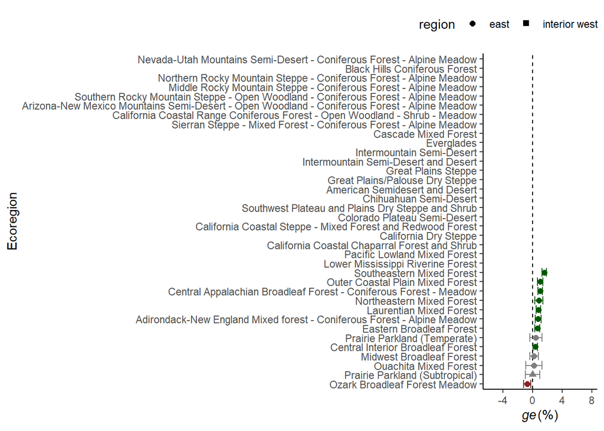

### map

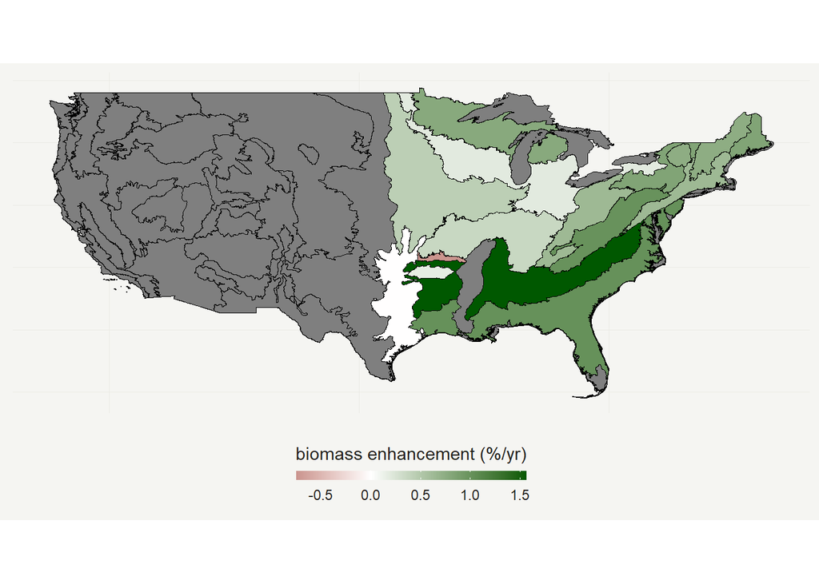

### map #2

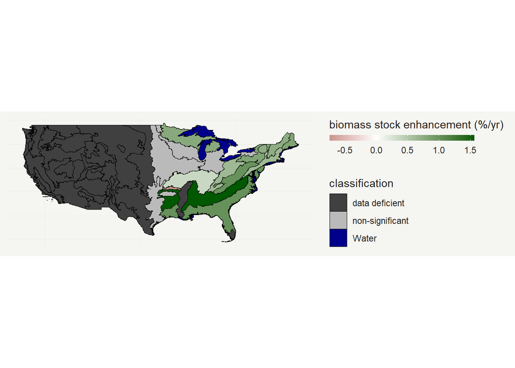

## plot phi (effect of DeltaPDSI)

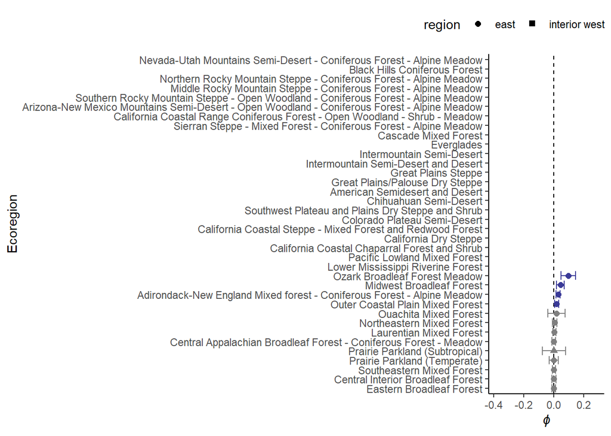

## plot alpha (biomass compensation effect)

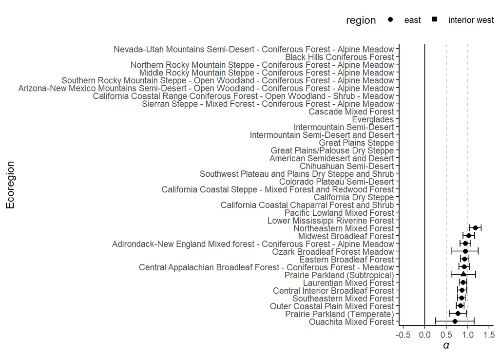

## plot a coefficient

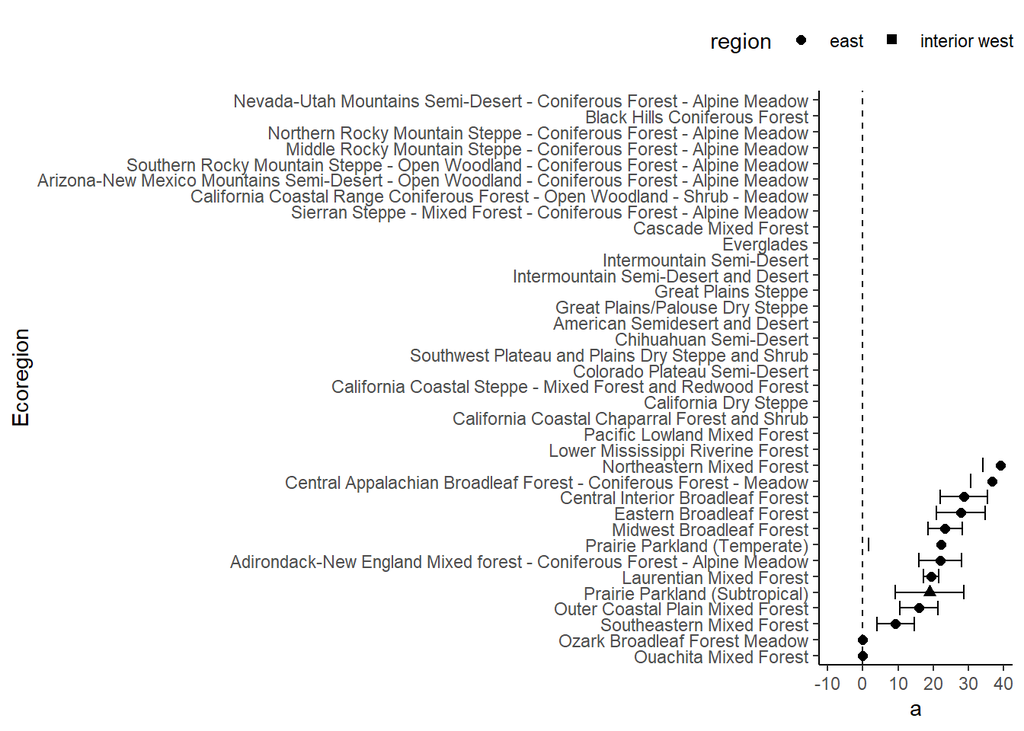

## plot b coefficient

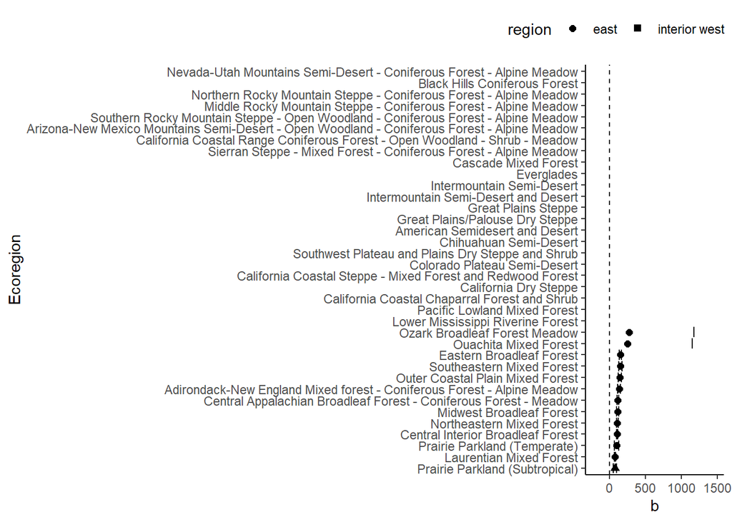

## plot c coefficient

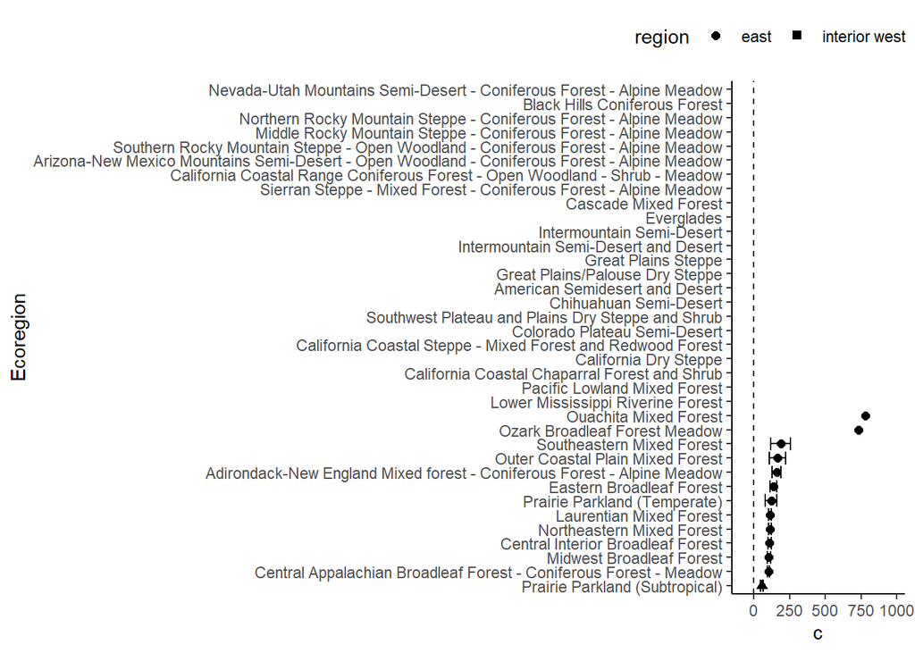

## plot d coefficient

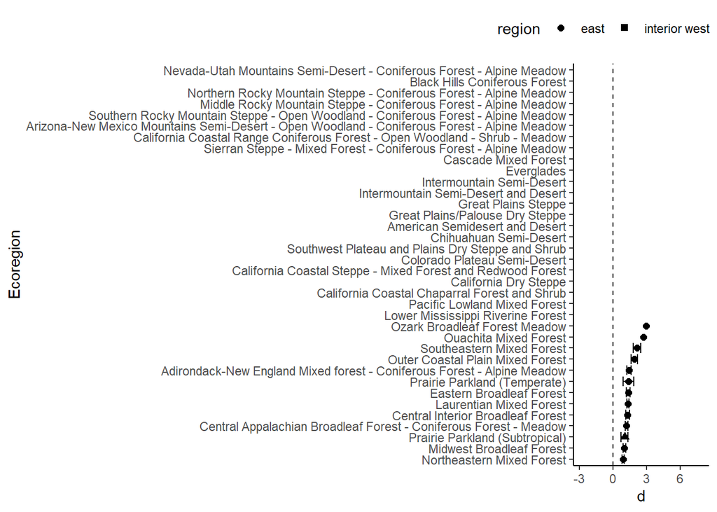

# Caclulations - weighted averages

## ge (stand biomass enhancement factor in % 2000-2021)

```
##          region  weighted.ge
## 1     entire US  0.780426754
## 2       pacific -0.006586837
## 3          east  0.793963909
## 4 interior west  0.000000000
```

## phi (effect of DeltaPDSI)

```
##          region weighted.phi
## 1     entire US  0.009137173
## 2       pacific  0.000000000
## 3          east  0.009295052
## 4 interior west  0.000000000
```

## alpha (biomass compensation effect)

```
##          region weighted.alpha
## 1     entire US      0.8900309
## 2       pacific      0.8840099
## 3          east      0.8983876
## 4 interior west      0.0000000
```

# Calculations - weighted averages subsetted to 15 ecoprovinces

- 211, 212, 221, 223, 231, 232, 234, 251, M211, M221, M223, M231, M242, M261, M332

## ge

```
##          region weighted.ge
## 1     entire US   0.8287371
## 2       pacific   0.0000000
## 3          east   0.8288806
## 4 interior west   0.0000000
```

## phi

```
##          region weighted.phi
## 1     entire US  0.007410959
## 2       pacific  0.000000000
## 3          east  0.007412242
## 4 interior west  0.000000000
```

## alpha

```
##          region weighted.alpha
## 1     entire US      0.8923441
## 2       pacific      0.0000000
## 3          east      0.8924986
## 4 interior west      0.0000000
```